# Práctica de Estadística descriptiva

Javier Herráez Albarrán

11/1/2022

## **Ejercicio 1**

Antes de comenzar el desarrollo del ejercicio, lo primero que tendremos que hacer será importar los datos de nuestro dataset, el cual contiene variables sobre jugadores de fútbol en el videojuego FIFA22, además de importar las librerías necesarias. Habiendo abierto el archivo, observamos que las variables basadas en carácteres son categóricas, por lo que usaremos la propiedad `as.is` para indicar que la única de estas variables que no debe tratar como factor sea la del nombre del jugador.

```r
library(dplyr)
players <- read.csv(file = "fifa22_players.csv", encoding = "UTF-8", as.is = 2)
```

#### A. Realiza un análisis descriptivo completo de los datos.

Lo primero que haremos será ver tanto el número de observaciones del set de datos como el número y los nombres de variables.

```r
# Cantidad total de filas
nrow(players)
```

```
## [1] 19260
```

```r
# Cantidad total de columnas
ncol(players)
```

```
## [1] 21
```

```r
# Nombres de columnas
colnames(players)
```

```
##  [1] "ID"                "Name"              "AttackingWorkRate"
##  [4] "DefensiveWorkRate" "PreferredFoot"     "ContractUntil"
##  [7] "Age"               "Height"            "Weight"
## [10] "Overall"           "Potential"         "ValueEUR"
## [13] "WageEUR"           "NationalTeam"      "ShootingTotal"
## [16] "PassingTotal"      "DribblingTotal"    "DefendingTotal"
## [19] "PhysicalityTotal"  "Growth"            "Volleys"
```

A continuación mostraremos las primeras observaciones para hacernos una idea de cómo serán nuestros datos.

```r
head(players)
```

```
##       ID              Name AttackingWorkRate DefensiveWorkRate PreferredFoot
## 1 158023          L. Messi            Medium               Low          Left
## 2 188545    R. Lewandowski              High            Medium         Right
## 3  20801 Cristiano Ronaldo              High               Low         Right
## 4 231747         K. Mbappé              High               Low         Right
## 5 200389          J. Oblak            Medium            Medium         Right
## 6 192985      K. De Bruyne              High              High         Right
##   ContractUntil Age Height Weight Overall Potential  ValueEUR WageEUR
## 1          2023  34    170     72      93        93  78000000  320000
## 2          2023  32    185     81      92        92 119500000  270000
## 3          2023  36    187     83      91        91  45000000  270000
## 4          2022  22    182     73      91        95 194000000  230000
## 5          2023  28    188     87      91        93 112000000  130000
## 6          2025  30    181     70      91        91 125500000  350000
##   NationalTeam ShootingTotal PassingTotal DribblingTotal DefendingTotal
## 1          Yes            92           91             95             34
## 2          Yes            92           79             85             44
## 3          Yes            94           80             87             34
## 4          Yes            88           80             92             36
## 5          Not            92           78             90             52
## 6          Yes            86           93             88             64
##   PhysicalityTotal Growth Volleys
## 1               65      0      88
## 2               82      0      89
## 3               75      0      86
## 4               77      4      83
## 5               90      2      13
## 6               78      0      82
```

Mostraremos también el tipo de las variables y ejemplos de contenido:

```r
str(players)
```

```
## 'data.frame':    19260 obs. of  21 variables:
##  $ ID               : int  158023 188545 20801 231747 200389 192985 190871 215914 202126 192448 ...
##  $ Name             : chr  "L. Messi" "R. Lewandowski" "Cristiano Ronaldo" "K. Mbappé" ...
##  $ AttackingWorkRate: Factor w/ 3 levels "High","Low","Medium": 3 1 1 1 3 1 1 3 1 3 ...
##  $ DefensiveWorkRate: Factor w/ 3 levels "High","Low","Medium": 2 3 2 2 3 1 3 1 1 3 ...
##  $ PreferredFoot    : Factor w/ 2 levels "Left","Right": 1 2 2 2 2 2 2 2 2 2 ...
##  $ ContractUntil    : int  2023 2023 2023 2022 2023 2025 2025 2023 2024 2025 ...
##  $ Age              : int  34 32 36 22 28 30 29 30 27 29 ...
##  $ Height           : int  170 185 187 182 188 181 175 168 188 187 ...
##  $ Weight           : int  72 81 83 73 87 70 68 70 89 85 ...
##  $ Overall          : int  93 92 91 91 91 91 91 90 90 90 ...
##  $ Potential        : int  93 92 91 95 93 91 91 90 90 92 ...
##  $ ValueEUR         : int  78000000 119500000 45000000 194000000 112000000 125500000 129000000 100000000 129500000 99000000 ...
##  $ WageEUR          : int  320000 270000 270000 230000 130000 350000 270000 230000 240000 250000 ...
##  $ NationalTeam     : Factor w/ 2 levels "Not","Yes": 2 2 2 2 1 2 1 2 2 1 ...
##  $ ShootingTotal    : int  92 92 94 88 92 86 83 66 91 85 ...
##  $ PassingTotal     : int  91 79 80 80 78 93 86 75 83 88 ...
##  $ DribblingTotal   : int  95 85 87 92 90 88 94 81 82 90 ...
##  $ DefendingTotal   : int  34 44 34 36 52 64 37 87 47 45 ...
##  $ PhysicalityTotal : int  65 82 75 77 90 78 63 83 83 88 ...
##  $ Growth           : int  0 0 0 4 2 0 0 0 0 2 ...
##  $ Volleys          : int  88 89 86 83 13 82 86 56 88 14 ...
```

También vemos un resumen estadístico de las variables.

```r
summary(players)
```

```
##        ID             Name           AttackingWorkRate DefensiveWorkRate
##  Min.   :    41   Length:19260       High  : 5595      High  : 3425
##  1st Qu.:214904   Class :character   Low   :  964      Low   : 1659
##  Median :236688   Mode  :character   Medium:12701      Medium:14176
##  Mean   :231683
##  3rd Qu.:253608
##  Max.   :264705
##
##  PreferredFoot ContractUntil       Age            Height          Weight
##  Left : 4590   Min.   :2021   Min.   :16.00   Min.   :155.0   Min.   : 49.00
##  Right:14670   1st Qu.:2022   1st Qu.:21.00   1st Qu.:176.0   1st Qu.: 70.00
##                Median :2022   Median :25.00   Median :181.0   Median : 75.00
##                Mean   :2023   Mean   :25.18   Mean   :181.3   Mean   : 74.95
##                3rd Qu.:2024   3rd Qu.:29.00   3rd Qu.:186.0   3rd Qu.: 80.00
##                Max.   :2031   Max.   :54.00   Max.   :206.0   Max.   :110.00
##                NA's   :76
##     Overall        Potential       ValueEUR            WageEUR
##  Min.   :48.00   Min.   :49.0   Min.   :        0   Min.   :     0
##  1st Qu.:62.00   1st Qu.:67.0   1st Qu.:   475000   1st Qu.:  1000
##  Median :66.00   Median :71.0   Median :   975000   Median :  3000
##  Mean   :65.82   Mean   :71.1   Mean   :  2857652   Mean   :  8974
##  3rd Qu.:70.00   3rd Qu.:75.0   3rd Qu.:  2000000   3rd Qu.:  8000
##  Max.   :93.00   Max.   :95.0   Max.   :194000000   Max.   :350000
##
##  NationalTeam ShootingTotal    PassingTotal   DribblingTotal  DefendingTotal
##  Not:18503    Min.   :18.00   Min.   :25.00   Min.   :26.00   Min.   :14.00
##  Yes:  757    1st Qu.:44.00   1st Qu.:52.00   1st Qu.:58.00   1st Qu.:35.00
##               Median :56.00   Median :58.00   Median :64.00   Median :54.00
##               Mean   :53.54   Mean   :57.85   Mean   :63.03   Mean   :50.06
##               3rd Qu.:64.00   3rd Qu.:65.00   3rd Qu.:69.00   3rd Qu.:63.00
##               Max.   :94.00   Max.   :93.00   Max.   :95.00   Max.   :91.00
##
##  PhysicalityTotal     Growth          Volleys
##  Min.   :29.00    Min.   : 0.000   Min.   : 3.0
##  1st Qu.:58.00    1st Qu.: 0.000   1st Qu.:30.0
##  Median :66.00    Median : 4.000   Median :43.0
##  Mean   :64.68    Mean   : 5.284   Mean   :42.5
##  3rd Qu.:72.00    3rd Qu.: 9.000   3rd Qu.:56.0
##  Max.   :92.00    Max.   :26.000   Max.   :90.0
##
```

A destacar que la variable ContractUntiles es la única con NAs con un total de 76.

Vamos a analizar si existe alguna observación repetida.

```r
count(players[duplicated(players),])
```

```
##     n
## 1 104
```

Vemos que existen 104 filas repetidas, por lo que procedemos a eliminarlas.

```r
players <- players[!duplicated(players),]
```

A continuación, generaremos unas gráficas relacionando cada variable con Overall, ya que es la variable más interesante y que trataremos más adelante como variable objetivo en un modelo de regresión lineal.

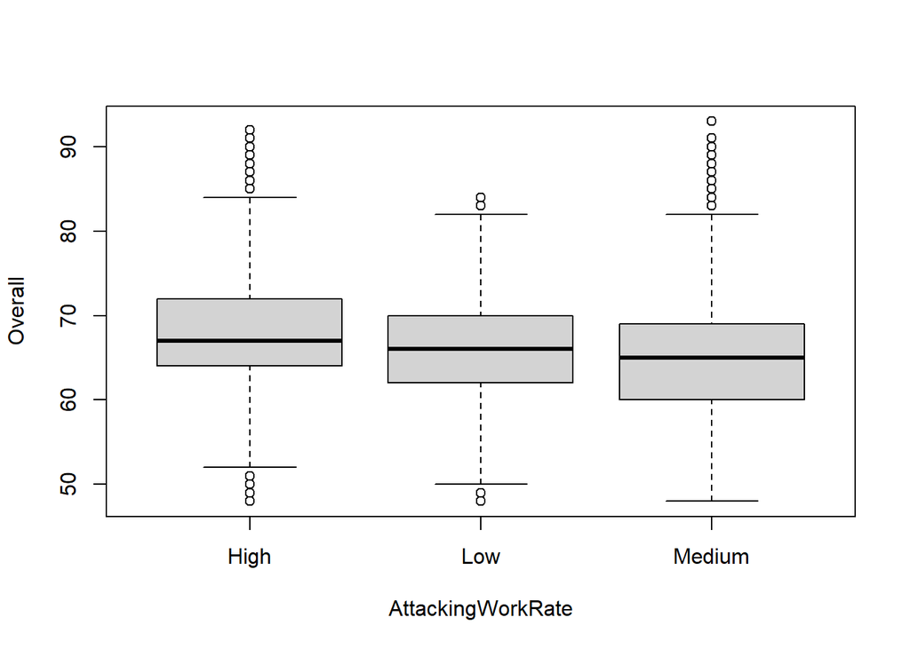

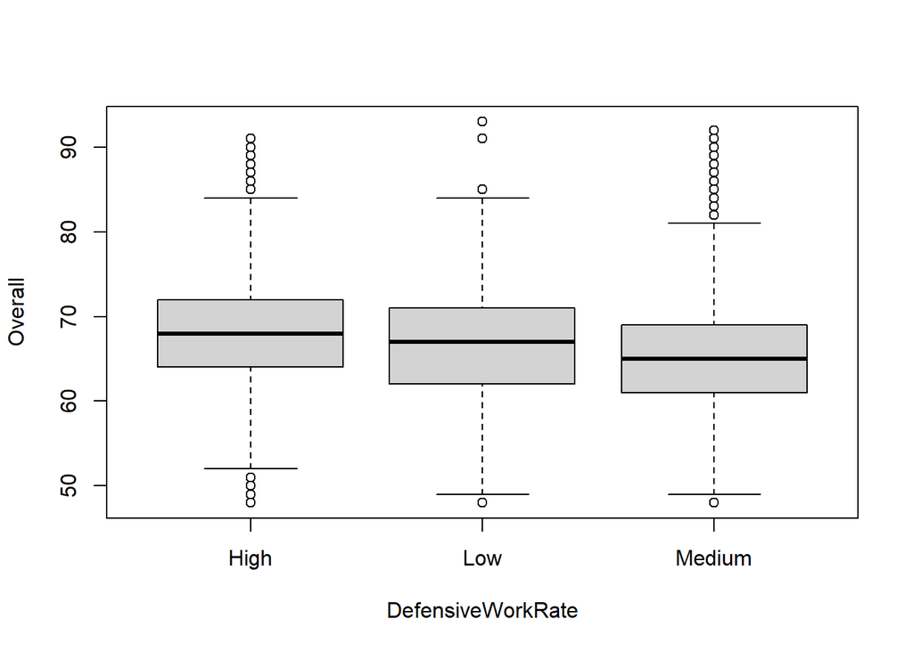

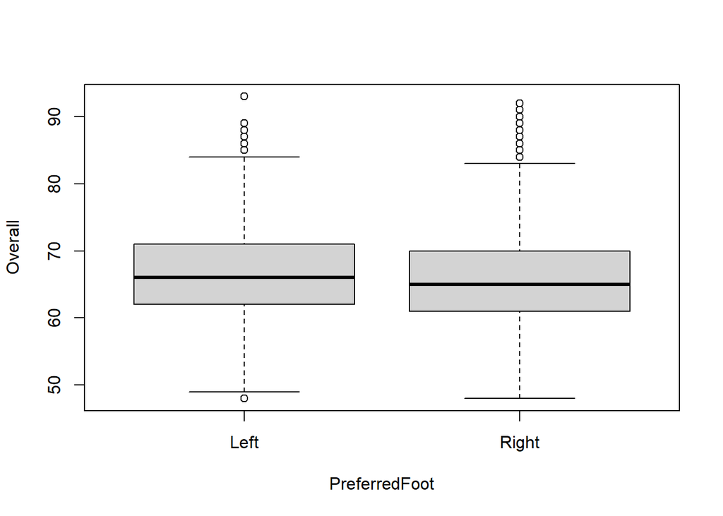

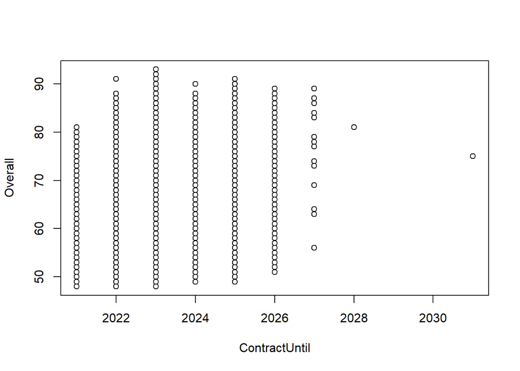

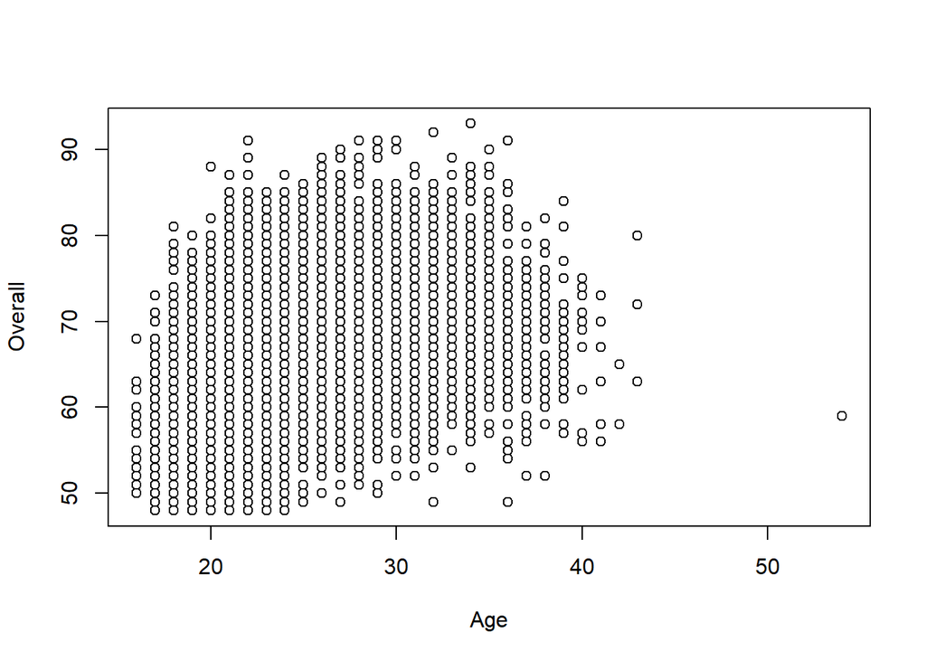

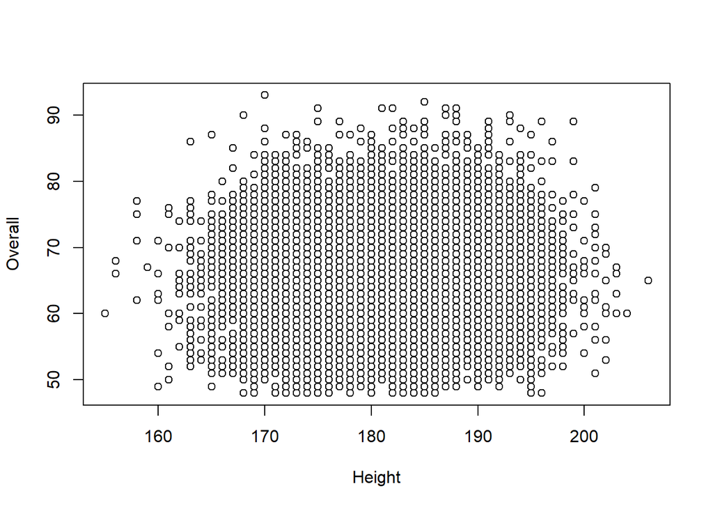

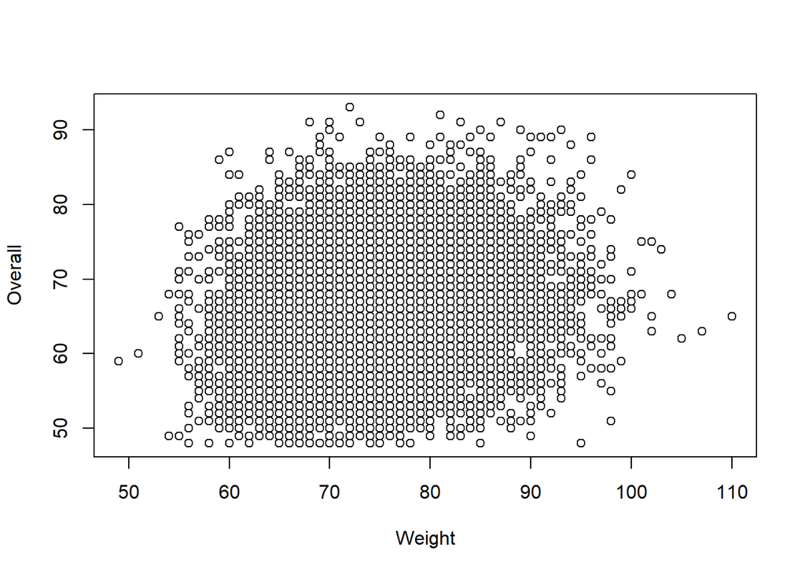

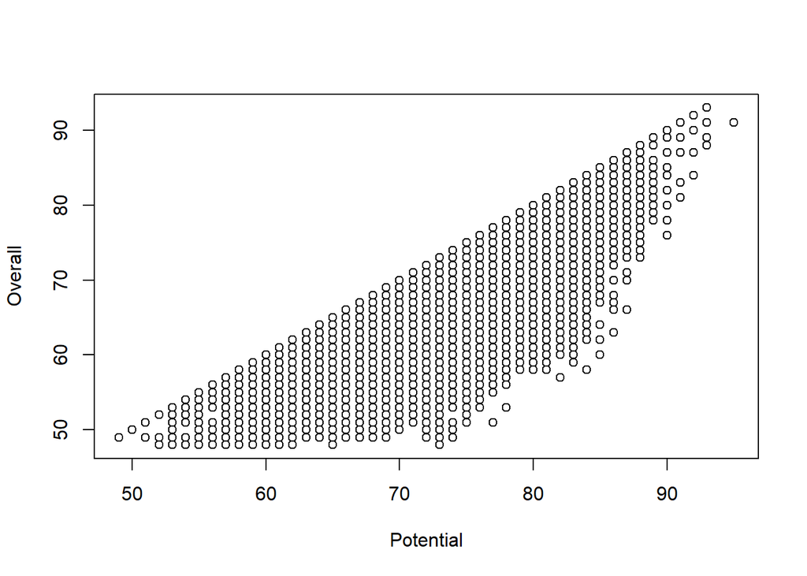

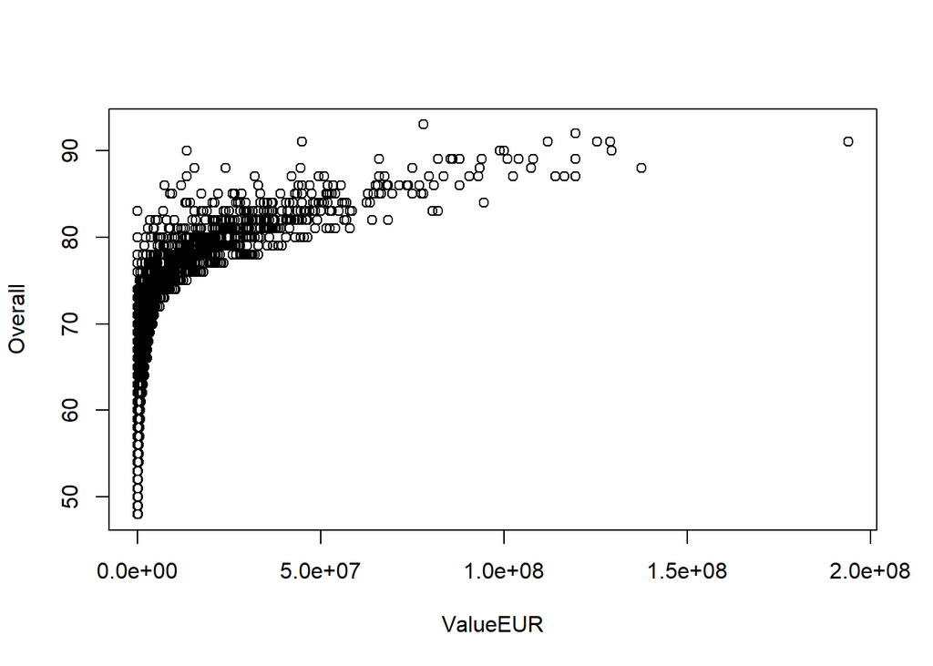

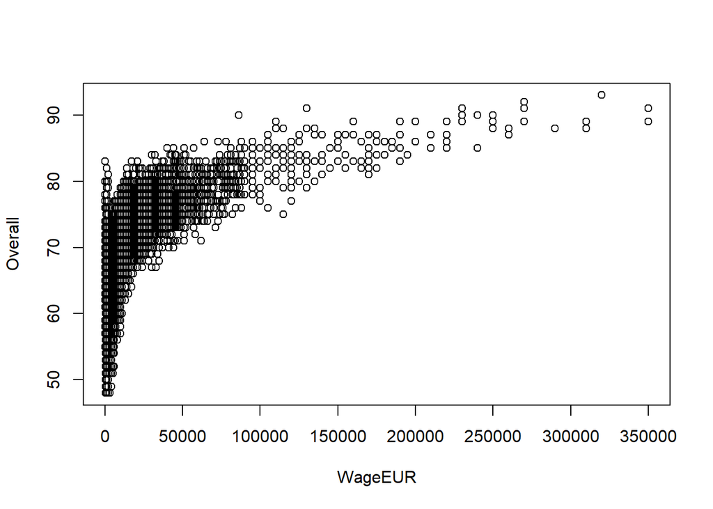

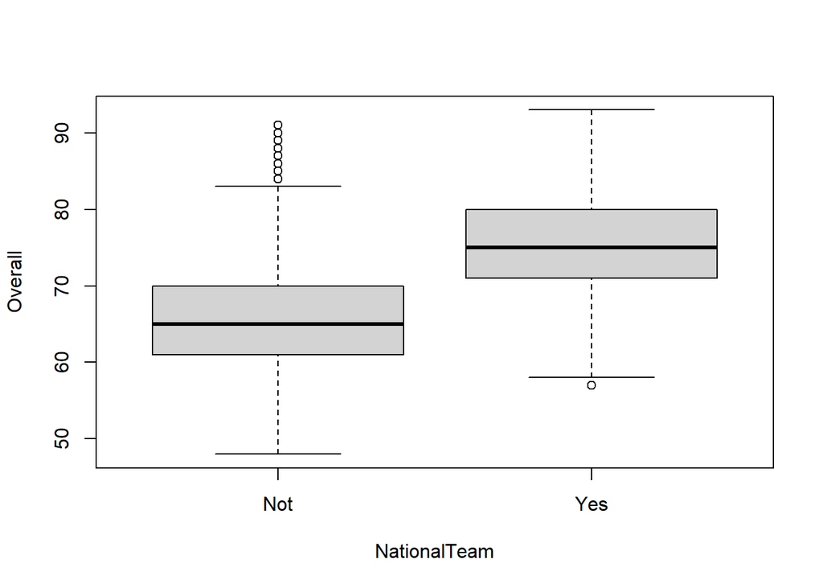

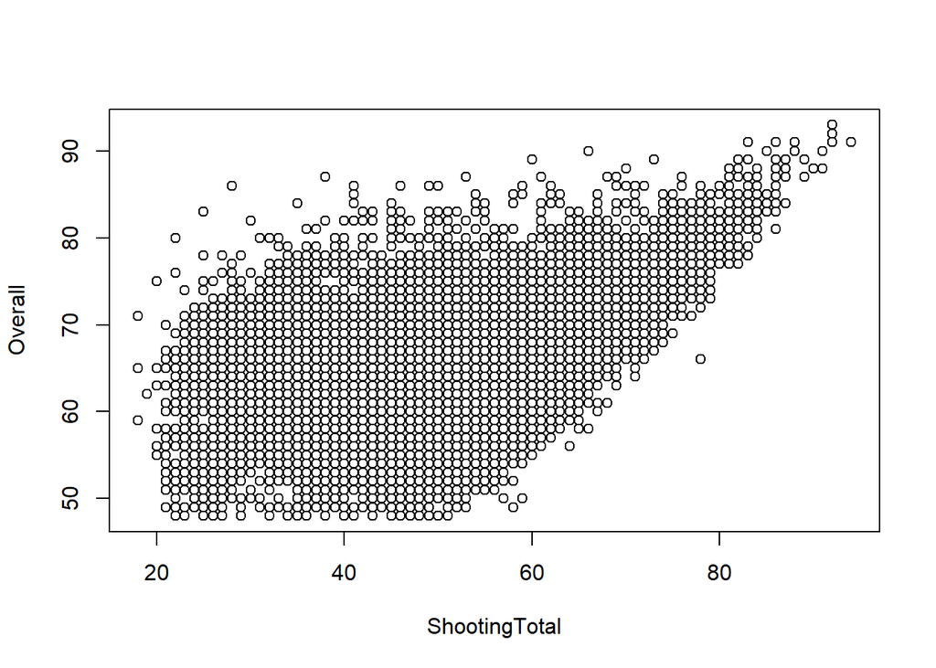

[6 more figures not shown]

```r
for(i in 1:ncol(players)){
  if(!colnames(players)[i] %in% c("Overall", "Name", "ID"))
    {
    plot(players[,i], players$Overall, type='p', xlab=names(players)[i], ylab="Overall")
  }
}
```

También, generamos un histograma para ver la distribución de Overall.

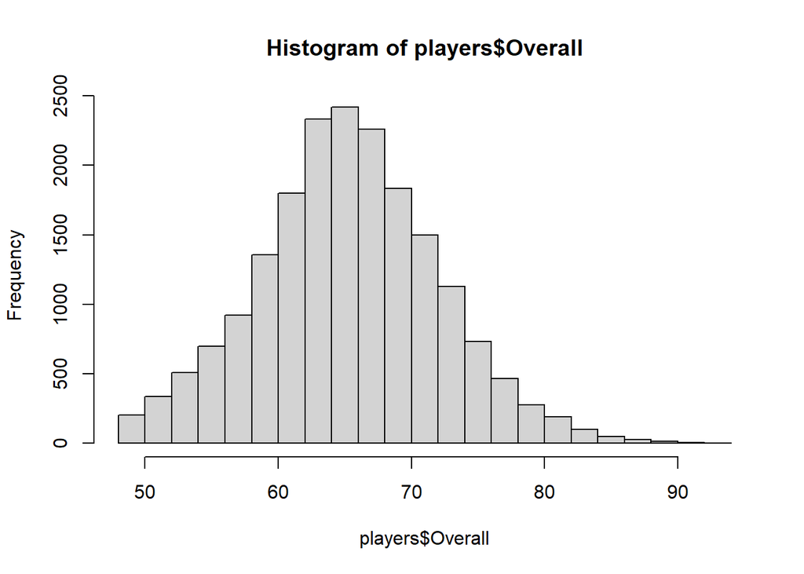

```r
hist(players$Overall, breaks = 20)
```

#### B. Ajusta un modelo de regresión lineal para predecir Overall usando las variables Age, NationalTeam, PreferredFoot, WageEUR, Growth, Volleys, ShootingTotal, PassingTotal, DribblingTotal, DefendingTotal y PhysicalityTotal.

Ajustamos un modelo con las variables que nos pide con el siguiente resultado:

```r
lm_fit_overall <- lm(Overall ~ Age + NationalTeam + PreferredFoot + WageEUR +
                       Growth + Volleys + ShootingTotal + PassingTotal +
                       DribblingTotal + DefendingTotal + PhysicalityTotal,
                     data = players)
summary(lm_fit_overall)
```

```
##
## Call:
## lm(formula = Overall ~ Age + NationalTeam + PreferredFoot + WageEUR +
##     Growth + Volleys + ShootingTotal + PassingTotal + DribblingTotal +
##     DefendingTotal + PhysicalityTotal, data = players)
##
## Residuals:
##      Min       1Q   Median       3Q      Max
## -17.4539  -1.9567  -0.1014   1.8782  13.7542
##
## Coefficients:
##                      Estimate Std. Error t value Pr(>|t|)
## (Intercept)         2.395e+01  3.788e-01  63.223   <2e-16 ***
## Age                 1.874e-02  9.162e-03   2.045   0.0408 *
## NationalTeamYes     1.020e+00  1.179e-01   8.654   <2e-16 ***
## PreferredFootRight -1.318e-01  5.067e-02  -2.601   0.0093 **
## WageEUR             7.729e-05  1.323e-06  58.438   <2e-16 ***
## Growth             -1.406e-01  8.174e-03 -17.204   <2e-16 ***
## Volleys             2.618e-02  1.472e-03  17.787   <2e-16 ***
## ShootingTotal       7.022e-03  3.611e-03   1.945   0.0518 .
## PassingTotal        4.601e-02  4.927e-03   9.338   <2e-16 ***
## DribblingTotal      3.059e-01  4.861e-03  62.927   <2e-16 ***
## DefendingTotal      7.524e-02  2.349e-03  32.033   <2e-16 ***
## PhysicalityTotal    2.210e-01  3.081e-03  71.717   <2e-16 ***
## ---
## Signif. codes:  0 '***' 0.001 '**' 0.01 '*' 0.05 '.' 0.1 ' ' 1
##
## Residual standard error: 2.941 on 19144 degrees of freedom
## Multiple R-squared:  0.8131, Adjusted R-squared:  0.813
## F-statistic:  7572 on 11 and 19144 DF,  p-value: < 2.2e-16
```

Es un modelo con un buen valor para Adjusted R-squared por lo que parece que está bastante bien como para ser utilizado. Sin embargo, viendo las gráficas que hemos mostrado en el descriptivo, creemos que podemos mejorarlo utilizando el logaritmo para la variable WageEUR.

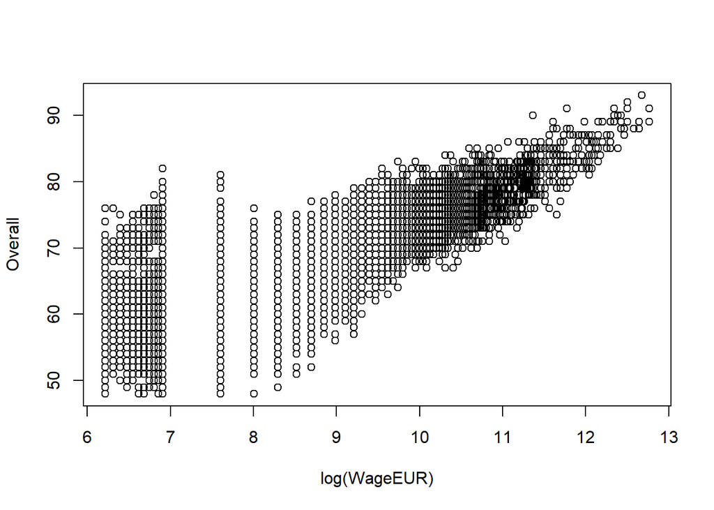

```r
plot(log(players$WageEUR), players$Overall, type='p', xlab="log(WageEUR)", ylab="Overall")
```

Sin embargo, tenemos un problema y es que existen ciertas observaciones con valores 0, lo que hace que nos salgan valores infinitos. Por lo tanto, hacemos un estudio de estos valores a ver que podemmos hacer con ellos.

```r
count(players[(players$WageEUR == 0), ])
```

```
##    n
## 1 76
```

```r
summary(players[(players$WageEUR == 0), ])
```

```
##        ID             Name           AttackingWorkRate DefensiveWorkRate
##  Min.   :154950   Length:76          High  :23         High  :22
##  1st Qu.:200047   Class :character   Low   : 6         Low   : 6
##  Median :232896   Mode  :character   Medium:47         Medium:48
##  Mean   :224390
##  3rd Qu.:247070
##  Max.   :264691
##
##  PreferredFoot ContractUntil      Age            Height          Weight
##  Left :13      Min.   : NA   Min.   :17.00   Min.   :166.0   Min.   :56.00
##  Right:63      1st Qu.: NA   1st Qu.:23.75   1st Qu.:180.0   1st Qu.:72.75
##                Median : NA   Median :28.00   Median :184.0   Median :78.00
##                Mean   :NaN   Mean   :27.34   Mean   :184.2   Mean   :77.78
##                3rd Qu.: NA   3rd Qu.:31.00   3rd Qu.:188.5   3rd Qu.:84.00
##                Max.   : NA   Max.   :38.00   Max.   :197.0   Max.   :95.00
##                NA's   :76
##     Overall        Potential        ValueEUR    WageEUR  NationalTeam
##  Min.   :55.00   Min.   :60.00   Min.   :0   Min.   :0   Not: 9
##  1st Qu.:64.00   1st Qu.:67.00   1st Qu.:0   1st Qu.:0   Yes:67
##  Median :68.00   Median :72.00   Median :0   Median :0
##  Mean   :67.71   Mean   :71.25   Mean   :0   Mean   :0
##  3rd Qu.:72.00   3rd Qu.:75.00   3rd Qu.:0   3rd Qu.:0
##  Max.   :83.00   Max.   :84.00   Max.   :0   Max.   :0
##
##  ShootingTotal    PassingTotal   DribblingTotal  DefendingTotal
##  Min.   :23.00   Min.   :37.00   Min.   :39.00   Min.   :21.00
##  1st Qu.:46.00   1st Qu.:53.00   1st Qu.:58.00   1st Qu.:38.00
##  Median :56.50   Median :61.00   Median :64.50   Median :59.50
##  Mean   :55.03   Mean   :59.53   Mean   :62.86   Mean   :53.29
##  3rd Qu.:66.25   3rd Qu.:68.00   3rd Qu.:70.25   3rd Qu.:67.00
##  Max.   :78.00   Max.   :75.00   Max.   :78.00   Max.   :86.00
##
##  PhysicalityTotal     Growth          Volleys
##  Min.   :39.00    Min.   : 0.000   Min.   : 6.00
##  1st Qu.:61.00    1st Qu.: 0.000   1st Qu.:31.00
##  Median :68.00    Median : 1.000   Median :43.50
##  Mean   :67.39    Mean   : 3.539   Mean   :42.43
##  3rd Qu.:74.00    3rd Qu.: 6.000   3rd Qu.:54.00
##  Max.   :86.00    Max.   :26.000   Max.   :75.00
##
```

Vemos que únicamente son 76 observaciones, que además coinciden con aquellas que tenían valores NAs en ContractUntil, lo cual tiene sentido ya que serán jugadores sin contrato. Al ser tan pocas observaciones, decidimos hacer un modelo sin ellas utilizando el logaritmo de WageEUR.

```r
players_with_contract <- players[(players$WageEUR != 0), ]

lm_fit_overall_contract <- lm(Overall ~ Age + NationalTeam + PreferredFoot + I(log(WageEUR)) +
                       Growth + Volleys + ShootingTotal + PassingTotal +
                       DribblingTotal + DefendingTotal + PhysicalityTotal,
                     data = players_with_contract)
summary(lm_fit_overall_contract)
```

```
##
## Call:
## lm(formula = Overall ~ Age + NationalTeam + PreferredFoot + I(log(WageEUR)) +
##     Growth + Volleys + ShootingTotal + PassingTotal + DribblingTotal +
##     DefendingTotal + PhysicalityTotal, data = players_with_contract)
##
## Residuals:
##      Min       1Q   Median       3Q      Max
## -11.7498  -1.7979  -0.1545   1.6785  13.9813
##
## Coefficients:
##                     Estimate Std. Error t value Pr(>|t|)
## (Intercept)        17.144429   0.344724  49.734  < 2e-16 ***
## Age                 0.041911   0.008573   4.889 1.02e-06 ***
## NationalTeamYes     1.749326   0.112181  15.594  < 2e-16 ***
## PreferredFootRight -0.089372   0.047292  -1.890   0.0588 .
## I(log(WageEUR))     1.687105   0.020517  82.228  < 2e-16 ***
## Growth             -0.103412   0.007642 -13.532  < 2e-16 ***
## Volleys             0.016945   0.001385  12.232  < 2e-16 ***
## ShootingTotal       0.001878   0.003373   0.557   0.5777
## PassingTotal        0.051822   0.004593  11.284  < 2e-16 ***
## DribblingTotal      0.252773   0.004632  54.567  < 2e-16 ***
## DefendingTotal      0.059753   0.002212  27.013  < 2e-16 ***
## PhysicalityTotal    0.181983   0.002954  61.611  < 2e-16 ***
## ---
## Signif. codes:  0 '***' 0.001 '**' 0.01 '*' 0.05 '.' 0.1 ' ' 1
##
## Residual standard error: 2.741 on 19068 degrees of freedom
## Multiple R-squared:  0.8378, Adjusted R-squared:  0.8377
## F-statistic:  8952 on 11 and 19068 DF,  p-value: < 2.2e-16
```

Se observa que mejora el Adjusted R-squared del anterior modelo, así que decidimos seguir trabajando con éste último.

#### C. Interpreta los coeficientes del modelo y descríbelo en forma de ecuación. Calcula los intervalos de los coeficientes al 95%.

Y los intervalos de los coeficientes al 95%:

```r
confint(lm_fit_overall_contract, level = 0.95)
```

```
##                           2.5 %       97.5 %
## (Intercept)        16.468740308 17.820118492
## Age                 0.025106827  0.058715464
## NationalTeamYes     1.529440720  1.969212014
## PreferredFootRight -0.182068970  0.003325247
## I(log(WageEUR))     1.646889068  1.727320526
## Growth             -0.118390801 -0.088432219
## Volleys             0.014230070  0.019660697
## ShootingTotal      -0.004733496  0.008489698
## PassingTotal        0.042820228  0.060824079
## DribblingTotal      0.243692996  0.261852436
## DefendingTotal      0.055416826  0.064088368
## PhysicalityTotal    0.176193277  0.187772396
```

#### D. ¿Cuáles de los predictores tienen una relación estadísticamente significativa con la variable respuesta? En base a esto, construye un modelo reducido que sólo emplee esos predictores, y compara su bondad de ajuste con el modelo anterior.

Los predictores que tienes una relación significativa con la variable respuesta son todos los utilizados a excepción de ShootingTotal y PreferredFootRight.

```r
lm_fit_overall_contract_reduced <- lm(Overall ~ Age + NationalTeam + I(log(WageEUR)) +
                       Growth + Volleys + PassingTotal +
                       DribblingTotal + DefendingTotal + PhysicalityTotal,
                     data = players_with_contract)
summary(lm_fit_overall_contract_reduced)
```

```
##
## Call:
## lm(formula = Overall ~ Age + NationalTeam + I(log(WageEUR)) +
##     Growth + Volleys + PassingTotal + DribblingTotal + DefendingTotal +
##     PhysicalityTotal, data = players_with_contract)
##
## Residuals:
##      Min       1Q   Median       3Q      Max
## -11.7814  -1.7964  -0.1491   1.6774  13.9566
##
## Coefficients:
##                   Estimate Std. Error t value Pr(>|t|)
## (Intercept)      17.054797   0.339693  50.206  < 2e-16 ***
## Age               0.042220   0.008492   4.972 6.69e-07 ***
## NationalTeamYes   1.750346   0.112119  15.612  < 2e-16 ***
## I(log(WageEUR))   1.687257   0.020508  82.275  < 2e-16 ***
## Growth           -0.103468   0.007630 -13.561  < 2e-16 ***
## Volleys           0.017290   0.001295  13.352  < 2e-16 ***
## PassingTotal      0.052900   0.004196  12.608  < 2e-16 ***
## DribblingTotal    0.253656   0.004462  56.848  < 2e-16 ***
## DefendingTotal    0.059265   0.001601  37.017  < 2e-16 ***
## PhysicalityTotal  0.182063   0.002813  64.723  < 2e-16 ***
## ---
## Signif. codes:  0 '***' 0.001 '**' 0.01 '*' 0.05 '.' 0.1 ' ' 1
##
## Residual standard error: 2.741 on 19070 degrees of freedom
## Multiple R-squared:  0.8377, Adjusted R-squared:  0.8377
## F-statistic: 1.094e+04 on 9 and 19070 DF,  p-value: < 2.2e-16
```

#### E. Estudia la existencia de outliers o high leverage points en este último modelo.

Se puede usar la función hatvalues para calcular el leverage de cada observación

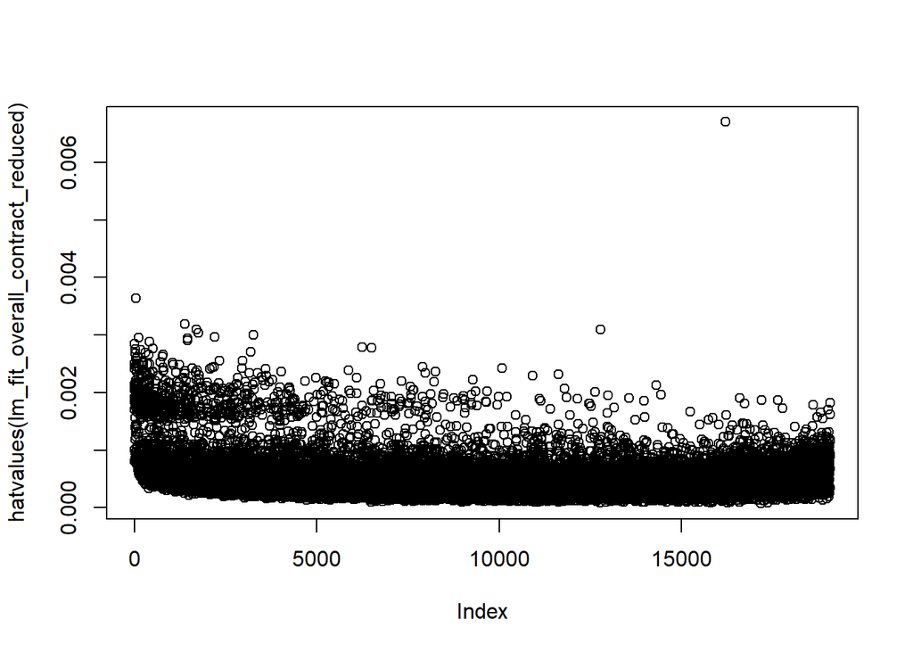

```r
plot(hatvalues(lm_fit_overall_contract_reduced))
```

También, para estimar la influencia de cada observación en el modelo final se puede utilizar la distancia de Cook, que combina la magnitud del residuo y el grado de leverage.

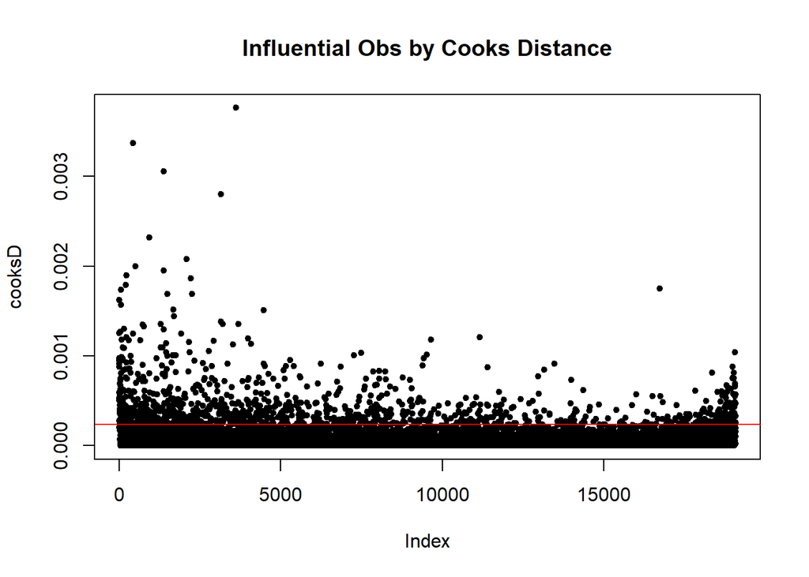

```r
cooksD <- cooks.distance(lm_fit_overall_contract_reduced)
plot(cooksD, pch=20, main="Influential Obs by Cooks Distance")
abline(h = 4*mean(cooksD), col='red')
```

Nos saldrían bastantes puntos con influencia:

```r
length(cooksD[cooksD > 4*mean(cooksD)])
```

```
## [1] 1042
```

Los puntos con mayor influencia corresponden con los siguientes índices:

```r
head(sort(cooksD, decreasing = T), n = 10)
```

```
##        3748         435        1396        3266         939        2197
## 0.003763965 0.003368383 0.003058766 0.002800646 0.002316321 0.002076176
##         500        1395         220        2327
## 0.001998626 0.001950959 0.001897997 0.001867216
```

```r
head(players[order(cooksD, decreasing = T), c('ID','Name')], n = 10)
```

```
##          ID         Name
## 3725 239272    V. Barkas
## 434  244470    V. Coufal
## 1387 242663   S. Bornauw
## 3247 224980     M. Busch
## 936  173521      Marcano
## 2186 237560   M. Djenepo
## 498  229927       Gerson
## 1386 244373 V. Buyalskyi
## 219  220697  J. Maddison
## 2316 253257   S. Cáceres
```